# Risk Factor Analysis

## Outcome Variable

**Outcome Variable:** ever_co

## Predictor Variables

**Intervention Variable:** perdiar24

**Adjustment Set:**

- arm
- sex
- hfoodsec
- W_birthwt
- W_birthlen
- W_nrooms
- month
- brthmon
- impfloor
- impsan
- safeh20
- delta_hfoodsec
- delta_W_birthwt
- delta_W_birthlen
- delta_W_nrooms
- delta_month
- delta_brthmon
- delta_impfloor
- delta_impsan
- delta_safeh20

## Stratifying Variables

The analysis was stratified on these variable(s):

- agecat
- studyid
- country

## Data Summary

| agecat | studyid | country | perdiar24 | ever_co | n_cell | n |
| --- | --- | --- | --- | --- | --- | --- |
| 0-24 months | ki0047075b-MAL-ED | BANGLADESH | 0% | 0 | 18 | 263 |
| 0-24 months | ki0047075b-MAL-ED | BANGLADESH | 0% | 1 | 2 | 263 |
| 0-24 months | ki0047075b-MAL-ED | BANGLADESH | (0%, 5%] | 0 | 125 | 263 |
| 0-24 months | ki0047075b-MAL-ED | BANGLADESH | (0%, 5%] | 1 | 23 | 263 |
| 0-24 months | ki0047075b-MAL-ED | BANGLADESH | >5% | 0 | 81 | 263 |
| 0-24 months | ki0047075b-MAL-ED | BANGLADESH | >5% | 1 | 14 | 263 |
| 0-24 months | ki0047075b-MAL-ED | BRAZIL | 0% | 0 | 130 | 233 |
| 0-24 months | ki0047075b-MAL-ED | BRAZIL | 0% | 1 | 0 | 233 |
| 0-24 months | ki0047075b-MAL-ED | BRAZIL | (0%, 5%] | 0 | 99 | 233 |
| 0-24 months | ki0047075b-MAL-ED | BRAZIL | (0%, 5%] | 1 | 2 | 233 |
| 0-24 months | ki0047075b-MAL-ED | BRAZIL | >5% | 0 | 2 | 233 |
| 0-24 months | ki0047075b-MAL-ED | BRAZIL | >5% | 1 | 0 | 233 |
| 0-24 months | ki0047075b-MAL-ED | INDIA | 0% | 0 | 13 | 251 |
| 0-24 months | ki0047075b-MAL-ED | INDIA | 0% | 1 | 1 | 251 |
| 0-24 months | ki0047075b-MAL-ED | INDIA | (0%, 5%] | 0 | 149 | 251 |
| 0-24 months | ki0047075b-MAL-ED | INDIA | (0%, 5%] | 1 | 44 | 251 |
| 0-24 months | ki0047075b-MAL-ED | INDIA | >5% | 0 | 35 | 251 |
| 0-24 months | ki0047075b-MAL-ED | INDIA | >5% | 1 | 9 | 251 |
| 0-24 months | ki0047075b-MAL-ED | NEPAL | 0% | 0 | 16 | 240 |
| 0-24 months | ki0047075b-MAL-ED | NEPAL | 0% | 1 | 1 | 240 |
| 0-24 months | ki0047075b-MAL-ED | NEPAL | (0%, 5%] | 0 | 130 | 240 |
| 0-24 months | ki0047075b-MAL-ED | NEPAL | (0%, 5%] | 1 | 14 | 240 |
| 0-24 months | ki0047075b-MAL-ED | NEPAL | >5% | 0 | 73 | 240 |
| 0-24 months | ki0047075b-MAL-ED | NEPAL | >5% | 1 | 6 | 240 |
| 0-24 months | ki0047075b-MAL-ED | PERU | 0% | 0 | 28 | 302 |
| 0-24 months | ki0047075b-MAL-ED | PERU | 0% | 1 | 0 | 302 |
| 0-24 months | ki0047075b-MAL-ED | PERU | (0%, 5%] | 0 | 108 | 302 |
| 0-24 months | ki0047075b-MAL-ED | PERU | (0%, 5%] | 1 | 5 | 302 |
| 0-24 months | ki0047075b-MAL-ED | PERU | >5% | 0 | 154 | 302 |
| 0-24 months | ki0047075b-MAL-ED | PERU | >5% | 1 | 7 | 302 |

[output cut: 342 more lines]

The following strata were considered:

- agecat: 0-24 months, studyid: ki0047075b-MAL-ED, country: BANGLADESH
- agecat: 0-24 months, studyid: ki0047075b-MAL-ED, country: BRAZIL
- agecat: 0-24 months, studyid: ki0047075b-MAL-ED, country: INDIA
- agecat: 0-24 months, studyid: ki0047075b-MAL-ED, country: NEPAL
- agecat: 0-24 months, studyid: ki0047075b-MAL-ED, country: PERU
- agecat: 0-24 months, studyid: ki0047075b-MAL-ED, country: SOUTH AFRICA
- agecat: 0-24 months, studyid: ki0047075b-MAL-ED, country: TANZANIA, UNITED REPUBLIC OF
- agecat: 0-24 months, studyid: ki1000109-EE, country: PAKISTAN
- agecat: 0-24 months, studyid: ki1000109-ResPak, country: PAKISTAN
- agecat: 0-24 months, studyid: ki1000304b-SAS-FoodSuppl, country: INDIA
- agecat: 0-24 months, studyid: ki1017093-NIH-Birth, country: BANGLADESH
- agecat: 0-24 months, studyid: ki1017093b-PROVIDE, country: BANGLADESH
- agecat: 0-24 months, studyid: ki1017093c-NIH-Crypto, country: BANGLADESH
- agecat: 0-24 months, studyid: ki1112895-Guatemala BSC, country: GUATEMALA
- agecat: 0-24 months, studyid: ki1112895-iLiNS-Zinc, country: BURKINA FASO
- agecat: 0-24 months, studyid: ki1114097-CMIN, country: BANGLADESH
- agecat: 0-24 months, studyid: ki1114097-CMIN, country: BRAZIL
- agecat: 0-24 months, studyid: ki1114097-CMIN, country: GUINEA-BISSAU
- agecat: 0-24 months, studyid: ki1114097-CMIN, country: PERU
- agecat: 0-24 months, studyid: ki1114097-CONTENT, country: PERU
- agecat: 0-24 months, studyid: kiGH5241-JiVitA-4, country: BANGLADESH
- agecat: 0-6 months, studyid: ki0047075b-MAL-ED, country: BANGLADESH
- agecat: 0-6 months, studyid: ki0047075b-MAL-ED, country: BRAZIL
- agecat: 0-6 months, studyid: ki0047075b-MAL-ED, country: INDIA
- agecat: 0-6 months, studyid: ki0047075b-MAL-ED, country: NEPAL
- agecat: 0-6 months, studyid: ki0047075b-MAL-ED, country: PERU
- agecat: 0-6 months, studyid: ki0047075b-MAL-ED, country: SOUTH AFRICA
- agecat: 0-6 months, studyid: ki0047075b-MAL-ED, country: TANZANIA, UNITED REPUBLIC OF
- agecat: 0-6 months, studyid: ki1000109-EE, country: PAKISTAN
- agecat: 0-6 months, studyid: ki1000109-ResPak, country: PAKISTAN
- agecat: 0-6 months, studyid: ki1000304b-SAS-FoodSuppl, country: INDIA
- agecat: 0-6 months, studyid: ki1017093-NIH-Birth, country: BANGLADESH
- agecat: 0-6 months, studyid: ki1017093b-PROVIDE, country: BANGLADESH
- agecat: 0-6 months, studyid: ki1017093c-NIH-Crypto, country: BANGLADESH
- agecat: 0-6 months, studyid: ki1112895-Guatemala BSC, country: GUATEMALA
- agecat: 0-6 months, studyid: ki1114097-CMIN, country: BANGLADESH
- agecat: 0-6 months, studyid: ki1114097-CMIN, country: BRAZIL
- agecat: 0-6 months, studyid: ki1114097-CMIN, country: GUINEA-BISSAU
- agecat: 0-6 months, studyid: ki1114097-CMIN, country: PERU
- agecat: 0-6 months, studyid: ki1114097-CONTENT, country: PERU
- agecat: 0-6 months, studyid: kiGH5241-JiVitA-4, country: BANGLADESH
- agecat: 6-24 months, studyid: ki0047075b-MAL-ED, country: BANGLADESH
- agecat: 6-24 months, studyid: ki0047075b-MAL-ED, country: BRAZIL
- agecat: 6-24 months, studyid: ki0047075b-MAL-ED, country: INDIA
- agecat: 6-24 months, studyid: ki0047075b-MAL-ED, country: NEPAL
- agecat: 6-24 months, studyid: ki0047075b-MAL-ED, country: PERU
- agecat: 6-24 months, studyid: ki0047075b-MAL-ED, country: SOUTH AFRICA
- agecat: 6-24 months, studyid: ki0047075b-MAL-ED, country: TANZANIA, UNITED REPUBLIC OF
- agecat: 6-24 months, studyid: ki1000109-EE, country: PAKISTAN
- agecat: 6-24 months, studyid: ki1000109-ResPak, country: PAKISTAN
- agecat: 6-24 months, studyid: ki1000304b-SAS-FoodSuppl, country: INDIA
- agecat: 6-24 months, studyid: ki1017093-NIH-Birth, country: BANGLADESH
- agecat: 6-24 months, studyid: ki1017093b-PROVIDE, country: BANGLADESH
- agecat: 6-24 months, studyid: ki1017093c-NIH-Crypto, country: BANGLADESH
- agecat: 6-24 months, studyid: ki1112895-Guatemala BSC, country: GUATEMALA
- agecat: 6-24 months, studyid: ki1112895-iLiNS-Zinc, country: BURKINA FASO
- agecat: 6-24 months, studyid: ki1114097-CMIN, country: BANGLADESH
- agecat: 6-24 months, studyid: ki1114097-CMIN, country: BRAZIL
- agecat: 6-24 months, studyid: ki1114097-CMIN, country: GUINEA-BISSAU
- agecat: 6-24 months, studyid: ki1114097-CMIN, country: PERU
- agecat: 6-24 months, studyid: ki1114097-CONTENT, country: PERU
- agecat: 6-24 months, studyid: kiGH5241-JiVitA-4, country: BANGLADESH

### Dropped Strata

Some strata were dropped due to rare outcomes:

- agecat: 0-24 months, studyid: ki0047075b-MAL-ED, country: BANGLADESH
- agecat: 0-24 months, studyid: ki0047075b-MAL-ED, country: BRAZIL
- agecat: 0-24 months, studyid: ki0047075b-MAL-ED, country: INDIA
- agecat: 0-24 months, studyid: ki0047075b-MAL-ED, country: NEPAL
- agecat: 0-24 months, studyid: ki0047075b-MAL-ED, country: PERU
- agecat: 0-24 months, studyid: ki0047075b-MAL-ED, country: SOUTH AFRICA
- agecat: 0-24 months, studyid: ki0047075b-MAL-ED, country: TANZANIA, UNITED REPUBLIC OF
- agecat: 0-24 months, studyid: ki1000109-ResPak, country: PAKISTAN
- agecat: 0-24 months, studyid: ki1017093-NIH-Birth, country: BANGLADESH
- agecat: 0-24 months, studyid: ki1017093b-PROVIDE, country: BANGLADESH
- agecat: 0-24 months, studyid: ki1112895-Guatemala BSC, country: GUATEMALA
- agecat: 0-24 months, studyid: ki1114097-CMIN, country: BANGLADESH
- agecat: 0-24 months, studyid: ki1114097-CMIN, country: BRAZIL
- agecat: 0-24 months, studyid: ki1114097-CMIN, country: PERU
- agecat: 0-24 months, studyid: ki1114097-CONTENT, country: PERU
- agecat: 0-6 months, studyid: ki0047075b-MAL-ED, country: BANGLADESH
- agecat: 0-6 months, studyid: ki0047075b-MAL-ED, country: BRAZIL
- agecat: 0-6 months, studyid: ki0047075b-MAL-ED, country: INDIA
- agecat: 0-6 months, studyid: ki0047075b-MAL-ED, country: NEPAL
- agecat: 0-6 months, studyid: ki0047075b-MAL-ED, country: PERU
- agecat: 0-6 months, studyid: ki0047075b-MAL-ED, country: SOUTH AFRICA
- agecat: 0-6 months, studyid: ki0047075b-MAL-ED, country: TANZANIA, UNITED REPUBLIC OF
- agecat: 0-6 months, studyid: ki1000109-EE, country: PAKISTAN
- agecat: 0-6 months, studyid: ki1000109-ResPak, country: PAKISTAN
- agecat: 0-6 months, studyid: ki1017093-NIH-Birth, country: BANGLADESH
- agecat: 0-6 months, studyid: ki1017093b-PROVIDE, country: BANGLADESH
- agecat: 0-6 months, studyid: ki1017093c-NIH-Crypto, country: BANGLADESH
- agecat: 0-6 months, studyid: ki1112895-Guatemala BSC, country: GUATEMALA
- agecat: 0-6 months, studyid: ki1114097-CMIN, country: BANGLADESH
- agecat: 0-6 months, studyid: ki1114097-CMIN, country: BRAZIL
- agecat: 0-6 months, studyid: ki1114097-CMIN, country: GUINEA-BISSAU
- agecat: 0-6 months, studyid: ki1114097-CMIN, country: PERU
- agecat: 0-6 months, studyid: ki1114097-CONTENT, country: PERU
- agecat: 6-24 months, studyid: ki0047075b-MAL-ED, country: BANGLADESH
- agecat: 6-24 months, studyid: ki0047075b-MAL-ED, country: BRAZIL
- agecat: 6-24 months, studyid: ki0047075b-MAL-ED, country: INDIA
- agecat: 6-24 months, studyid: ki0047075b-MAL-ED, country: NEPAL
- agecat: 6-24 months, studyid: ki0047075b-MAL-ED, country: PERU
- agecat: 6-24 months, studyid: ki0047075b-MAL-ED, country: SOUTH AFRICA
- agecat: 6-24 months, studyid: ki0047075b-MAL-ED, country: TANZANIA, UNITED REPUBLIC OF
- agecat: 6-24 months, studyid: ki1000109-ResPak, country: PAKISTAN
- agecat: 6-24 months, studyid: ki1017093-NIH-Birth, country: BANGLADESH
- agecat: 6-24 months, studyid: ki1017093b-PROVIDE, country: BANGLADESH
- agecat: 6-24 months, studyid: ki1112895-Guatemala BSC, country: GUATEMALA
- agecat: 6-24 months, studyid: ki1114097-CMIN, country: BANGLADESH
- agecat: 6-24 months, studyid: ki1114097-CMIN, country: BRAZIL
- agecat: 6-24 months, studyid: ki1114097-CMIN, country: PERU
- agecat: 6-24 months, studyid: ki1114097-CONTENT, country: PERU

## Methods Detail

We’re interested in the causal parameters $E[Y_a]$ for all values of $a \in \mathcal{A}$. These parameters represent the mean outcome if, possibly contrary to fact, we intervened to set all units to have $A=a$. Under the randomization and positivity assumptions, these are identified by the statistical parameters $\psi_a=E_W[E_{Y|A,W}(Y|A=a,W)]$. In addition, we’re interested in the mean of $Y$, $E[Y]$ under no intervention (the observed mean). We will estimate these parameters by using SuperLearner to fit the relevant likelihood factors – $E_{Y|A,W}(Y|A=a,W)$ and $p(A=a|W)$, and then updating our likelihood fit using a joint TMLE.

For unadjusted analyses ($W=\{\}$), initial likelihoods were estimated using Lrnr_glm to estimate the simple $E(Y|A)$ and Lrnr_mean to estimate $p(A)$. For adjusted analyses, a small library containing Lrnr_glmnet, Lrnr_xgboost, and Lrnr_mean was used.

Having estimated these parameters, we will then use the delta method to estimate relative risks and attributable risks relative to a prespecified baseline level of $A$.

# Results Detail

## Results Plots

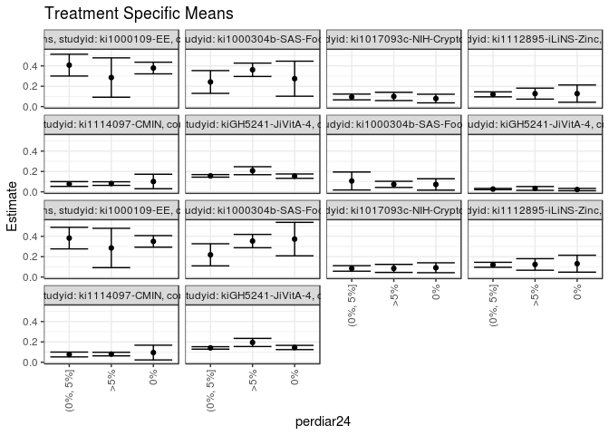

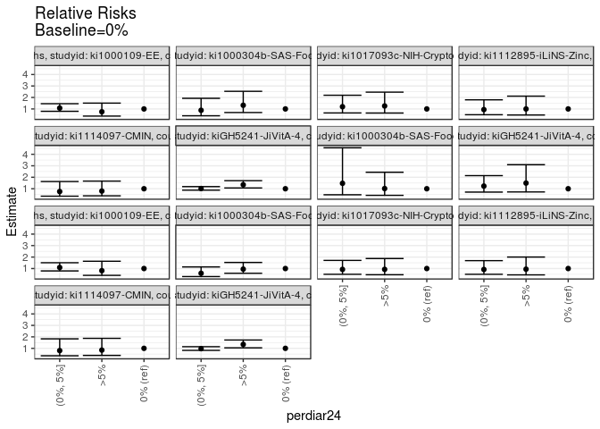

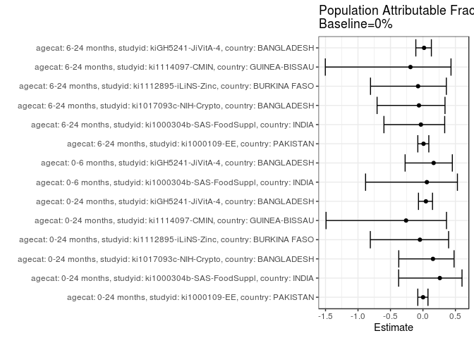

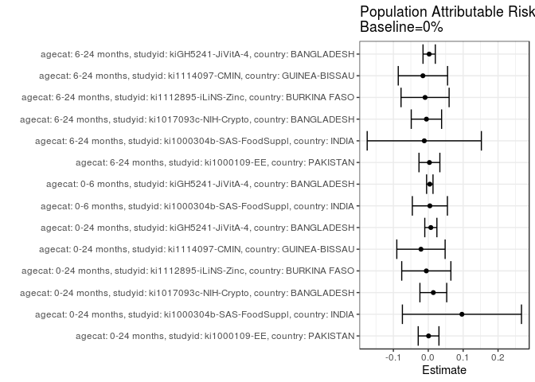

## Results Table

### Parameter: TSM

| agecat | studyid | country | intervention_level | baseline_level | estimate | ci_lower | ci_upper |
| --- | --- | --- | --- | --- | --- | --- | --- |
| 0-24 months | ki1000109-EE | PAKISTAN | 0% | NA | 0.3790614 | 0.3218528 | 0.4362699 |
| 0-24 months | ki1000109-EE | PAKISTAN | (0%, 5%] | NA | 0.4074074 | 0.3002624 | 0.5145524 |
| 0-24 months | ki1000109-EE | PAKISTAN | >5% | NA | 0.2857143 | 0.0922441 | 0.4791845 |
| 0-24 months | ki1000304b-SAS-FoodSuppl | INDIA | 0% | NA | 0.2743160 | 0.1021654 | 0.4464666 |
| 0-24 months | ki1000304b-SAS-FoodSuppl | INDIA | (0%, 5%] | NA | 0.2418117 | 0.1300127 | 0.3536107 |
| 0-24 months | ki1000304b-SAS-FoodSuppl | INDIA | >5% | NA | 0.3617988 | 0.2962763 | 0.4273213 |
| 0-24 months | ki1017093c-NIH-Crypto | BANGLADESH | 0% | NA | 0.0791797 | 0.0366995 | 0.1216599 |
| 0-24 months | ki1017093c-NIH-Crypto | BANGLADESH | (0%, 5%] | NA | 0.0945499 | 0.0663234 | 0.1227763 |
| 0-24 months | ki1017093c-NIH-Crypto | BANGLADESH | >5% | NA | 0.0996933 | 0.0590375 | 0.1403491 |
| 0-24 months | ki1112895-iLiNS-Zinc | BURKINA FASO | 0% | NA | 0.1275736 | 0.0425719 | 0.2125753 |
| 0-24 months | ki1112895-iLiNS-Zinc | BURKINA FASO | (0%, 5%] | NA | 0.1202471 | 0.0958205 | 0.1446738 |
| 0-24 months | ki1112895-iLiNS-Zinc | BURKINA FASO | >5% | NA | 0.1273986 | 0.0734298 | 0.1813673 |
| 0-24 months | ki1114097-CMIN | GUINEA-BISSAU | 0% | NA | 0.1014493 | 0.0301859 | 0.1727126 |
| 0-24 months | ki1114097-CMIN | GUINEA-BISSAU | (0%, 5%] | NA | 0.0767677 | 0.0533072 | 0.1002282 |
| 0-24 months | ki1114097-CMIN | GUINEA-BISSAU | >5% | NA | 0.0809628 | 0.0632727 | 0.0986529 |
| 0-24 months | kiGH5241-JiVitA-4 | BANGLADESH | 0% | NA | 0.1539836 | 0.1326251 | 0.1753421 |
| 0-24 months | kiGH5241-JiVitA-4 | BANGLADESH | (0%, 5%] | NA | 0.1567973 | 0.1441745 | 0.1694201 |
| 0-24 months | kiGH5241-JiVitA-4 | BANGLADESH | >5% | NA | 0.2074133 | 0.1681992 | 0.2466273 |
| 0-6 months | ki1000304b-SAS-FoodSuppl | INDIA | 0% | NA | 0.0722892 | 0.0165097 | 0.1280686 |
| 0-6 months | ki1000304b-SAS-FoodSuppl | INDIA | (0%, 5%] | NA | 0.1063830 | 0.0181291 | 0.1946368 |
| 0-6 months | ki1000304b-SAS-FoodSuppl | INDIA | >5% | NA | 0.0734266 | 0.0431606 | 0.1036925 |
| 0-6 months | kiGH5241-JiVitA-4 | BANGLADESH | 0% | NA | 0.0221409 | 0.0109303 | 0.0333515 |
| 0-6 months | kiGH5241-JiVitA-4 | BANGLADESH | (0%, 5%] | NA | 0.0272610 | 0.0210404 | 0.0334815 |
| 0-6 months | kiGH5241-JiVitA-4 | BANGLADESH | >5% | NA | 0.0330496 | 0.0144189 | 0.0516804 |
| 6-24 months | ki1000109-EE | PAKISTAN | 0% | NA | 0.3505535 | 0.2936688 | 0.4074382 |
| 6-24 months | ki1000109-EE | PAKISTAN | (0%, 5%] | NA | 0.3827160 | 0.2767250 | 0.4887071 |
| 6-24 months | ki1000109-EE | PAKISTAN | >5% | NA | 0.2857143 | 0.0922400 | 0.4791886 |
| 6-24 months | ki1000304b-SAS-FoodSuppl | INDIA | 0% | NA | 0.3730082 | 0.2084227 | 0.5375936 |
| 6-24 months | ki1000304b-SAS-FoodSuppl | INDIA | (0%, 5%] | NA | 0.2185414 | 0.1098295 | 0.3272533 |
| 6-24 months | ki1000304b-SAS-FoodSuppl | INDIA | >5% | NA | 0.3534389 | 0.2878092 | 0.4190687 |
| 6-24 months | ki1017093c-NIH-Crypto | BANGLADESH | 0% | NA | 0.0915905 | 0.0429246 | 0.1402564 |
| 6-24 months | ki1017093c-NIH-Crypto | BANGLADESH | (0%, 5%] | NA | 0.0846420 | 0.0575220 | 0.1117619 |
| 6-24 months | ki1017093c-NIH-Crypto | BANGLADESH | >5% | NA | 0.0849349 | 0.0454364 | 0.1244334 |
| 6-24 months | ki1112895-iLiNS-Zinc | BURKINA FASO | 0% | NA | 0.1310889 | 0.0476731 | 0.2145047 |
| 6-24 months | ki1112895-iLiNS-Zinc | BURKINA FASO | (0%, 5%] | NA | 0.1203779 | 0.0958534 | 0.1449025 |
| 6-24 months | ki1112895-iLiNS-Zinc | BURKINA FASO | >5% | NA | 0.1237682 | 0.0669939 | 0.1805424 |
| 6-24 months | ki1114097-CMIN | GUINEA-BISSAU | 0% | NA | 0.0952381 | 0.0227278 | 0.1677484 |
| 6-24 months | ki1114097-CMIN | GUINEA-BISSAU | (0%, 5%] | NA | 0.0764463 | 0.0527661 | 0.1001264 |
| 6-24 months | ki1114097-CMIN | GUINEA-BISSAU | >5% | NA | 0.0806630 | 0.0629150 | 0.0984109 |
| 6-24 months | kiGH5241-JiVitA-4 | BANGLADESH | 0% | NA | 0.1451412 | 0.1242472 | 0.1660353 |
| 6-24 months | kiGH5241-JiVitA-4 | BANGLADESH | (0%, 5%] | NA | 0.1409301 | 0.1288876 | 0.1529725 |
| 6-24 months | kiGH5241-JiVitA-4 | BANGLADESH | >5% | NA | 0.1946764 | 0.1547798 | 0.2345729 |

### Parameter: E(Y)

| agecat | studyid | country | intervention_level | baseline_level | estimate | ci_lower | ci_upper |
| --- | --- | --- | --- | --- | --- | --- | --- |
| 0-24 months | ki1000109-EE | PAKISTAN | NA | NA | 0.3799472 | 0.3310169 | 0.4288776 |
| 0-24 months | ki1000304b-SAS-FoodSuppl | INDIA | NA | NA | 0.3708134 | 0.3244530 | 0.4171738 |
| 0-24 months | ki1017093c-NIH-Crypto | BANGLADESH | NA | NA | 0.0936675 | 0.0729118 | 0.1144233 |
| 0-24 months | ki1112895-iLiNS-Zinc | BURKINA FASO | NA | NA | 0.1219413 | 0.0960094 | 0.1478731 |
| 0-24 months | ki1114097-CMIN | GUINEA-BISSAU | NA | NA | 0.0805142 | 0.0666381 | 0.0943903 |
| 0-24 months | kiGH5241-JiVitA-4 | BANGLADESH | NA | NA | 0.1613377 | 0.1500062 | 0.1726692 |
| 0-6 months | ki1000304b-SAS-FoodSuppl | INDIA | NA | NA | 0.0769231 | 0.0512858 | 0.1025603 |
| 0-6 months | kiGH5241-JiVitA-4 | BANGLADESH | NA | NA | 0.0265122 | 0.0211694 | 0.0318550 |
| 6-24 months | ki1000109-EE | PAKISTAN | NA | NA | 0.3538874 | 0.3052956 | 0.4024792 |
| 6-24 months | ki1000304b-SAS-FoodSuppl | INDIA | NA | NA | 0.3615960 | 0.3145115 | 0.4086805 |
| 6-24 months | ki1017093c-NIH-Crypto | BANGLADESH | NA | NA | 0.0863014 | 0.0659171 | 0.1066856 |
| 6-24 months | ki1112895-iLiNS-Zinc | BURKINA FASO | NA | NA | 0.1219413 | 0.0960094 | 0.1478731 |
| 6-24 months | ki1114097-CMIN | GUINEA-BISSAU | NA | NA | 0.0798898 | 0.0659396 | 0.0938400 |
| 6-24 months | kiGH5241-JiVitA-4 | BANGLADESH | NA | NA | 0.1477252 | 0.1371297 | 0.1583206 |

### Parameter: RR

| agecat | studyid | country | intervention_level | baseline_level | estimate | ci_lower | ci_upper |
| --- | --- | --- | --- | --- | --- | --- | --- |
| 0-24 months | ki1000109-EE | PAKISTAN | 0% | 0% | 1.0000000 | 1.0000000 | 1.000000 |
| 0-24 months | ki1000109-EE | PAKISTAN | (0%, 5%] | 0% | 1.0747795 | 0.7936567 | 1.455480 |
| 0-24 months | ki1000109-EE | PAKISTAN | >5% | 0% | 0.7537415 | 0.3766397 | 1.508408 |
| 0-24 months | ki1000304b-SAS-FoodSuppl | INDIA | 0% | 0% | 1.0000000 | 1.0000000 | 1.000000 |
| 0-24 months | ki1000304b-SAS-FoodSuppl | INDIA | (0%, 5%] | 0% | 0.8815079 | 0.4035630 | 1.925489 |
| 0-24 months | ki1000304b-SAS-FoodSuppl | INDIA | >5% | 0% | 1.3189126 | 0.6860444 | 2.535595 |
| 0-24 months | ki1017093c-NIH-Crypto | BANGLADESH | 0% | 0% | 1.0000000 | 1.0000000 | 1.000000 |
| 0-24 months | ki1017093c-NIH-Crypto | BANGLADESH | (0%, 5%] | 0% | 1.1941175 | 0.6498335 | 2.194280 |
| 0-24 months | ki1017093c-NIH-Crypto | BANGLADESH | >5% | 0% | 1.2590768 | 0.6440031 | 2.461594 |
| 0-24 months | ki1112895-iLiNS-Zinc | BURKINA FASO | 0% | 0% | 1.0000000 | 1.0000000 | 1.000000 |
| 0-24 months | ki1112895-iLiNS-Zinc | BURKINA FASO | (0%, 5%] | 0% | 0.9425707 | 0.4954988 | 1.793020 |
| 0-24 months | ki1112895-iLiNS-Zinc | BURKINA FASO | >5% | 0% | 0.9986281 | 0.4712100 | 2.116377 |
| 0-24 months | ki1114097-CMIN | GUINEA-BISSAU | 0% | 0% | 1.0000000 | 1.0000000 | 1.000000 |
| 0-24 months | ki1114097-CMIN | GUINEA-BISSAU | (0%, 5%] | 0% | 0.7567100 | 0.3517529 | 1.627875 |
| 0-24 months | ki1114097-CMIN | GUINEA-BISSAU | >5% | 0% | 0.7980619 | 0.3824263 | 1.665426 |
| 0-24 months | kiGH5241-JiVitA-4 | BANGLADESH | 0% | 0% | 1.0000000 | 1.0000000 | 1.000000 |
| 0-24 months | kiGH5241-JiVitA-4 | BANGLADESH | (0%, 5%] | 0% | 1.0182727 | 0.8754565 | 1.184387 |
| 0-24 months | kiGH5241-JiVitA-4 | BANGLADESH | >5% | 0% | 1.3469829 | 1.0664081 | 1.701378 |
| 0-6 months | ki1000304b-SAS-FoodSuppl | INDIA | 0% | 0% | 1.0000000 | 1.0000000 | 1.000000 |
| 0-6 months | ki1000304b-SAS-FoodSuppl | INDIA | (0%, 5%] | 0% | 1.4716312 | 0.4739794 | 4.569182 |
| 0-6 months | ki1000304b-SAS-FoodSuppl | INDIA | >5% | 0% | 1.0157343 | 0.4235009 | 2.436161 |
| 0-6 months | kiGH5241-JiVitA-4 | BANGLADESH | 0% | 0% | 1.0000000 | 1.0000000 | 1.000000 |
| 0-6 months | kiGH5241-JiVitA-4 | BANGLADESH | (0%, 5%] | 0% | 1.2312496 | 0.7076322 | 2.142322 |
| 0-6 months | kiGH5241-JiVitA-4 | BANGLADESH | >5% | 0% | 1.4926971 | 0.7197026 | 3.095924 |
| 6-24 months | ki1000109-EE | PAKISTAN | 0% | 0% | 1.0000000 | 1.0000000 | 1.000000 |
| 6-24 months | ki1000109-EE | PAKISTAN | (0%, 5%] | 0% | 1.0917479 | 0.7919927 | 1.504955 |
| 6-24 months | ki1000109-EE | PAKISTAN | >5% | 0% | 0.8150376 | 0.4062231 | 1.635274 |
| 6-24 months | ki1000304b-SAS-FoodSuppl | INDIA | 0% | 0% | 1.0000000 | 1.0000000 | 1.000000 |
| 6-24 months | ki1000304b-SAS-FoodSuppl | INDIA | (0%, 5%] | 0% | 0.5858891 | 0.3010627 | 1.140181 |
| 6-24 months | ki1000304b-SAS-FoodSuppl | INDIA | >5% | 0% | 0.9475367 | 0.5868488 | 1.529910 |
| 6-24 months | ki1017093c-NIH-Crypto | BANGLADESH | 0% | 0% | 1.0000000 | 1.0000000 | 1.000000 |
| 6-24 months | ki1017093c-NIH-Crypto | BANGLADESH | (0%, 5%] | 0% | 0.9241349 | 0.4999978 | 1.708058 |
| 6-24 months | ki1017093c-NIH-Crypto | BANGLADESH | >5% | 0% | 0.9273332 | 0.4595263 | 1.871377 |
| 6-24 months | ki1112895-iLiNS-Zinc | BURKINA FASO | 0% | 0% | 1.0000000 | 1.0000000 | 1.000000 |
| 6-24 months | ki1112895-iLiNS-Zinc | BURKINA FASO | (0%, 5%] | 0% | 0.9182923 | 0.4992456 | 1.689070 |
| 6-24 months | ki1112895-iLiNS-Zinc | BURKINA FASO | >5% | 0% | 0.9441545 | 0.4452754 | 2.001969 |
| 6-24 months | ki1114097-CMIN | GUINEA-BISSAU | 0% | 0% | 1.0000000 | 1.0000000 | 1.000000 |
| 6-24 months | ki1114097-CMIN | GUINEA-BISSAU | (0%, 5%] | 0% | 0.8026860 | 0.3528359 | 1.826075 |
| 6-24 months | ki1114097-CMIN | GUINEA-BISSAU | >5% | 0% | 0.8469613 | 0.3834239 | 1.870889 |
| 6-24 months | kiGH5241-JiVitA-4 | BANGLADESH | 0% | 0% | 1.0000000 | 1.0000000 | 1.000000 |
| 6-24 months | kiGH5241-JiVitA-4 | BANGLADESH | (0%, 5%] | 0% | 0.9709858 | 0.8236306 | 1.144704 |
| 6-24 months | kiGH5241-JiVitA-4 | BANGLADESH | >5% | 0% | 1.3412894 | 1.0435572 | 1.723966 |

### Parameter: PAR

| agecat | studyid | country | intervention_level | baseline_level | estimate | ci_lower | ci_upper |
| --- | --- | --- | --- | --- | --- | --- | --- |
| 0-24 months | ki1000109-EE | PAKISTAN | 0% | NA | 0.0008859 | -0.0288291 | 0.0306009 |
| 0-24 months | ki1000304b-SAS-FoodSuppl | INDIA | 0% | NA | 0.0964974 | -0.0741510 | 0.2671458 |
| 0-24 months | ki1017093c-NIH-Crypto | BANGLADESH | 0% | NA | 0.0144878 | -0.0239370 | 0.0529127 |
| 0-24 months | ki1112895-iLiNS-Zinc | BURKINA FASO | 0% | NA | -0.0056323 | -0.0760875 | 0.0648229 |
| 0-24 months | ki1114097-CMIN | GUINEA-BISSAU | 0% | NA | -0.0209351 | -0.0901943 | 0.0483241 |
| 0-24 months | kiGH5241-JiVitA-4 | BANGLADESH | 0% | NA | 0.0073541 | -0.0099995 | 0.0247078 |
| 0-6 months | ki1000304b-SAS-FoodSuppl | INDIA | 0% | NA | 0.0046339 | -0.0456361 | 0.0549039 |
| 0-6 months | kiGH5241-JiVitA-4 | BANGLADESH | 0% | NA | 0.0043713 | -0.0048326 | 0.0135752 |
| 6-24 months | ki1000109-EE | PAKISTAN | 0% | NA | 0.0033339 | -0.0265835 | 0.0332513 |
| 6-24 months | ki1000304b-SAS-FoodSuppl | INDIA | 0% | NA | -0.0114122 | -0.1750587 | 0.1522344 |
| 6-24 months | ki1017093c-NIH-Crypto | BANGLADESH | 0% | NA | -0.0052891 | -0.0487897 | 0.0382114 |
| 6-24 months | ki1112895-iLiNS-Zinc | BURKINA FASO | 0% | NA | -0.0091476 | -0.0780477 | 0.0597525 |
| 6-24 months | ki1114097-CMIN | GUINEA-BISSAU | 0% | NA | -0.0153483 | -0.0860314 | 0.0553348 |
| 6-24 months | kiGH5241-JiVitA-4 | BANGLADESH | 0% | NA | 0.0025840 | -0.0150445 | 0.0202124 |

### Parameter: PAF

| agecat | studyid | country | intervention_level | baseline_level | estimate | ci_lower | ci_upper |
| --- | --- | --- | --- | --- | --- | --- | --- |
| 0-24 months | ki1000109-EE | PAKISTAN | 0% | NA | 0.0023315 | -0.0790239 | 0.0775530 |
| 0-24 months | ki1000304b-SAS-FoodSuppl | INDIA | 0% | NA | 0.2602317 | -0.3739274 | 0.6016842 |
| 0-24 months | ki1017093c-NIH-Crypto | BANGLADESH | 0% | NA | 0.1546729 | -0.3720926 | 0.4792058 |
| 0-24 months | ki1112895-iLiNS-Zinc | BURKINA FASO | 0% | NA | -0.0461888 | -0.8101463 | 0.3953466 |
| 0-24 months | ki1114097-CMIN | GUINEA-BISSAU | 0% | NA | -0.2600171 | -1.4920380 | 0.3629138 |
| 0-24 months | kiGH5241-JiVitA-4 | BANGLADESH | 0% | NA | 0.0455823 | -0.0685695 | 0.1475397 |
| 0-6 months | ki1000304b-SAS-FoodSuppl | INDIA | 0% | NA | 0.0602410 | -0.8832383 | 0.5310487 |
| 0-6 months | kiGH5241-JiVitA-4 | BANGLADESH | 0% | NA | 0.1648788 | -0.2742904 | 0.4526935 |
| 6-24 months | ki1000109-EE | PAKISTAN | 0% | NA | 0.0094208 | -0.0788317 | 0.0904539 |
| 6-24 months | ki1000304b-SAS-FoodSuppl | INDIA | 0% | NA | -0.0315605 | -0.6004825 | 0.3351273 |
| 6-24 months | ki1017093c-NIH-Crypto | BANGLADESH | 0% | NA | -0.0612866 | -0.7060117 | 0.3397880 |
| 6-24 months | ki1112895-iLiNS-Zinc | BURKINA FASO | 0% | NA | -0.0750165 | -0.8070902 | 0.3604854 |
| 6-24 months | ki1114097-CMIN | GUINEA-BISSAU | 0% | NA | -0.1921182 | -1.5029787 | 0.4322181 |
| 6-24 months | kiGH5241-JiVitA-4 | BANGLADESH | 0% | NA | 0.0174916 | -0.1094496 | 0.1299084 |